# AuMgO / cumulene / bio_dimers: checkpoint-parity diagnostics from `metawork-54`

## 5. Cumulene: warm-started fine-tune, training snapshot

**Snapshot only** -- `cumulene_long_run_metrics.txt` was copied while `metawork-54`'s training run was still in progress (epoch 89 of a planned 200, append-only CSV so reading mid-run is safe). Re-copy the file and re-run this cell for an updated curve; this notebook will not update itself automatically.

Train loss is falling steadily (with periodic spikes, likely batch composition or an LR-schedule restart), but the sparse validation RMSE (every 10th epoch) is essentially flat around 5 eV / 60 eV/Å and not obviously improving over these 90 epochs -- worth `metawork-54` keeping an eye on as the run continues.

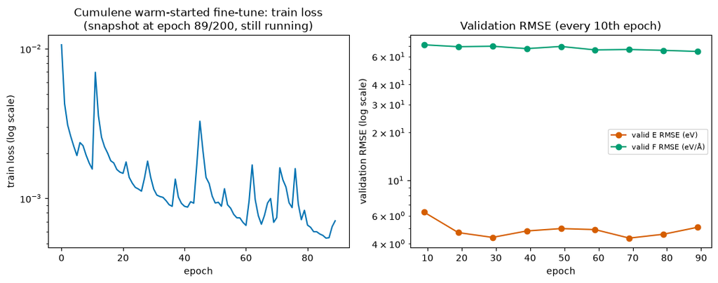

```python
data = np.genfromtxt("metawork54_results/cumulene_long_run_metrics.txt", delimiter=",", names=True)
epoch, train_loss = data["epoch"], data["train_loss"]
valid_e, valid_f = data["valid_e_rmse"], data["valid_f_rmse"]
valid_mask = ~np.isnan(valid_e)

fig, axes = plt.subplots(1, 2, figsize=(11, 4.4))
ax = axes[0]
ax.semilogy(epoch, train_loss, color=BLUE, linewidth=1.5)
ax.set_xlabel("epoch"); ax.set_ylabel("train loss (log scale)")
ax.set_title(f"Cumulene warm-started fine-tune: train loss\n(snapshot at epoch {int(epoch.max())}/200, still running)")

ax = axes[1]
ax.semilogy(epoch[valid_mask], valid_e[valid_mask], "o-", color="#D55E00", label="valid E RMSE (eV)")
ax.semilogy(epoch[valid_mask], valid_f[valid_mask], "o-", color="#009E73", label="valid F RMSE (eV/Å)")
ax.set_xlabel("epoch"); ax.set_ylabel("validation RMSE (log scale)")
ax.set_title("Validation RMSE (every 10th epoch)")
ax.legend(fontsize=8)
fig.tight_layout()
```

## 6. bio_dimers smoke test -- diagnostic only, NOT a validated result (superseded, see section 9)

`metawork-54` has **no torch-side array** for bio_dimers -- only jax-side energies/potentials generated while diagnosing a bug; the smoke-test's torch-side output was only printed to that session's own background task stdout, which isn't recoverable from here. This surfaced a real, still-open torch-pme vs jax-pme Ewald-potential discrepancy (the same family as section 4's AuMgO finding) -- treat the plots below as "what jax alone predicts", not a parity check.

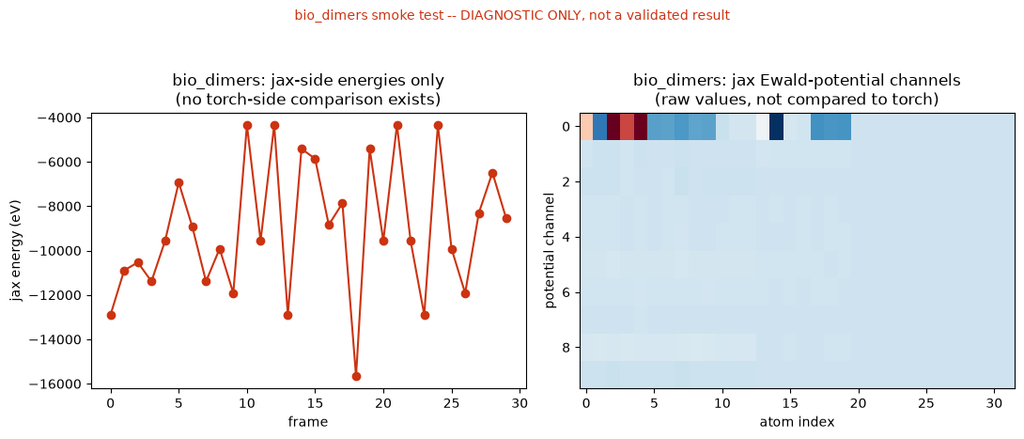

```python
be = np.load("metawork54_results/bio_dimers_jax_energies_30.npy")
bp = np.load("metawork54_results/bio_dimers_jax_potentials_recomputed.npy")

fig, axes = plt.subplots(1, 2, figsize=(11, 4.4))
ax = axes[0]
ax.plot(range(len(be)), be, "o-", color="#CC3311")
ax.set_xlabel("frame"); ax.set_ylabel("jax energy (eV)")
ax.set_title("bio_dimers: jax-side energies only\n(no torch-side comparison exists)")

ax = axes[1]
ax.imshow(bp.T, aspect="auto", cmap="RdBu_r")
ax.set_xlabel("atom index"); ax.set_ylabel("potential channel")
ax.set_title("bio_dimers: jax Ewald-potential channels\n(raw values, not compared to torch)")
fig.suptitle(
    "bio_dimers smoke test -- DIAGNOSTIC ONLY, not a validated result",
    y=1.05, color="#CC3311", fontsize=10,
)
fig.tight_layout()
```

## 9. bio_dimers: full validated result (ran this myself, not a diagnostic anymore)

200 frames from `bio_dimers_test.xyz` (periodic, 30x30x30 Å box, Ewald), checkpoint `evals/bio_dimers/lorem/run/checkpoints/R2_E+F`, after the section 7 fix. Two different things are being measured:

1. **Checkpoint-loading fidelity** (torch port vs. JAX reference) -- does the torch port reproduce the *same checkpoint's* predictions as running it in JAX? A weight-transfer/numerics check, nothing to do with model quality.
2. **Model accuracy vs. DFT** -- how good is that checkpoint against the real DFT labels? This is the number the paper itself reports (0.222 meV/atom energy RMSE, 1.646 meV/Å forces, full 13,743-frame test set).

Data + reproduction commands: `metawork`'s `etc/lorem-parity/jax_checkpoint_parity/RESULTS_bio_dimers.md`.

```
energy vs JAX RMSE: 0.000108 meV/atom  (float32 noise floor)
energy vs DFT RMSE: 0.2415 meV/atom  (paper: 0.222)
forces vs JAX RMSE: 0.002711 meV/Å
forces vs DFT RMSE: 1.7325 meV/Å  (paper: 1.646)
```

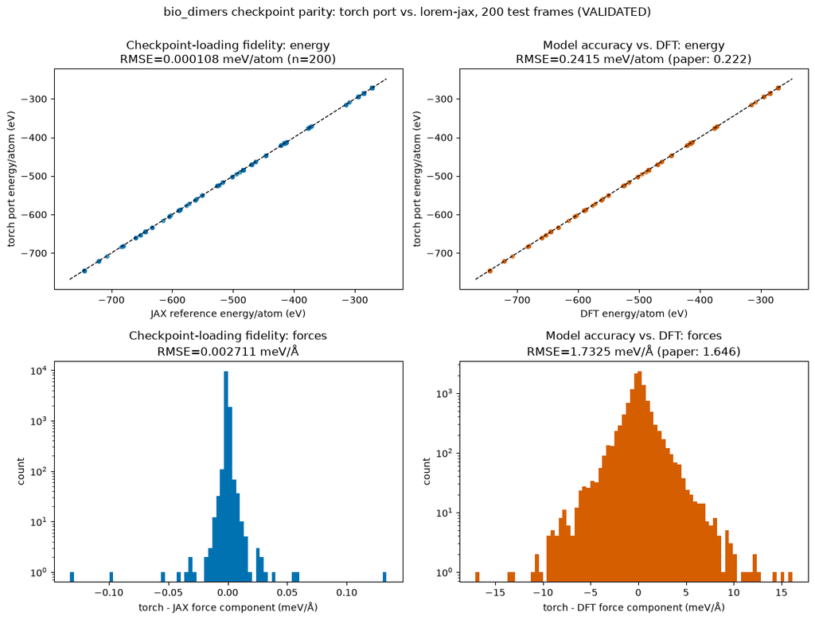

```python
bd = np.load("metawork54_results/bio_dimers_parity_200frames.npz")
bt_e, bj_e, bd_e = bd["torch_energies"], bd["jax_energies"], bd["dft_energies"]
bsizes = bd["sizes"]
bt_f, bj_f, bd_f = bd["torch_forces"], bd["jax_forces"], bd["dft_forces"]

e_vs_jax = (bt_e - bj_e) / bsizes * 1000
e_vs_dft = (bt_e - bd_e) / bsizes * 1000
f_vs_jax = (bt_f - bj_f) * 1000
f_vs_dft = (bt_f - bd_f) * 1000
n_frames = len(bt_e)

fig, axes = plt.subplots(2, 2, figsize=(12, 9))

ax = axes[0, 0]
ax.scatter(bj_e / bsizes, bt_e / bsizes, s=14, color="#0072B2", alpha=0.7)
lo, hi = (bj_e / bsizes).min(), (bj_e / bsizes).max()
pad = (hi - lo) * 0.05
ax.plot([lo - pad, hi + pad], [lo - pad, hi + pad], "k--", lw=1)
ax.set_xlabel("JAX reference energy/atom (eV)"); ax.set_ylabel("torch port energy/atom (eV)")
ax.set_title(f"Checkpoint-loading fidelity: energy\nRMSE={np.sqrt(np.mean(e_vs_jax**2)):.6f} meV/atom (n={n_frames})")

ax = axes[0, 1]
ax.scatter(bd_e / bsizes, bt_e / bsizes, s=14, color="#D55E00", alpha=0.7)
lo, hi = (bd_e / bsizes).min(), (bd_e / bsizes).max()
pad = (hi - lo) * 0.05
ax.plot([lo - pad, hi + pad], [lo - pad, hi + pad], "k--", lw=1)
ax.set_xlabel("DFT energy/atom (eV)"); ax.set_ylabel("torch port energy/atom (eV)")
ax.set_title(f"Model accuracy vs. DFT: energy\nRMSE={np.sqrt(np.mean(e_vs_dft**2)):.4f} meV/atom (paper: 0.222)")

ax = axes[1, 0]
ax.hist(f_vs_jax.ravel(), bins=80, color="#0072B2")
ax.set_yscale("log")
ax.set_xlabel("torch - JAX force component (meV/Å)"); ax.set_ylabel("count")
ax.set_title(f"Checkpoint-loading fidelity: forces\nRMSE={np.sqrt(np.mean(f_vs_jax**2)):.6f} meV/Å")

ax = axes[1, 1]
ax.hist(f_vs_dft.ravel(), bins=80, color="#D55E00")
ax.set_yscale("log")
ax.set_xlabel("torch - DFT force component (meV/Å)"); ax.set_ylabel("count")
ax.set_title(f"Model accuracy vs. DFT: forces\nRMSE={np.sqrt(np.mean(f_vs_dft**2)):.4f} meV/Å (paper: 1.646)")

fig.suptitle("bio_dimers checkpoint parity: torch port vs. lorem-jax, 200 test frames (VALIDATED)", y=1.0)
fig.tight_layout()

print(f"energy vs JAX RMSE: {np.sqrt(np.mean(e_vs_jax**2)):.6f} meV/atom  (float32 noise floor)")
print(f"energy vs DFT RMSE: {np.sqrt(np.mean(e_vs_dft**2)):.4f} meV/atom  (paper: 0.222)")
print(f"forces vs JAX RMSE: {np.sqrt(np.mean(f_vs_jax**2)):.6f} meV/Å")
print(f"forces vs DFT RMSE: {np.sqrt(np.mean(f_vs_dft**2)):.4f} meV/Å  (paper: 1.646)")
```

## Takeaways (updated)

**Original takeaways (sections 1-6, before the fix) are kept above for the record of the investigation** -- how the bug was chased down is as useful as the fix itself. Current state:

- **SR (short-range) parity was always essentially exact** for AuMgO (`Dense_0` through `Update_1`, `MLP_0`/`MLP_1`: diffs at the float32 noise floor) -- same solid ground as the SN2 port (`15_long_range_scan_lorem_jax_ported_torch.ipynb`).
- **LR (long-range) parity is now also exact.** The ~0.06-0.19 eV AuMgO energy gap and the much larger bio_dimers gap were **the same single bug**: `JaxParityLongRange` set `exclusion_radius=neighbor_list_options.cutoff` on its Ewald calculator, copied from a different (intentionally restructured) production class. lorem-jax's own `Ewald()` always uses `exclusion_radius=None`. Removing that one argument, and using marathon's real smearing formula (`cutoff/4`, `cutoff/8`) instead of a `tune_ewald` guess, fixed both periodic checkpoints: